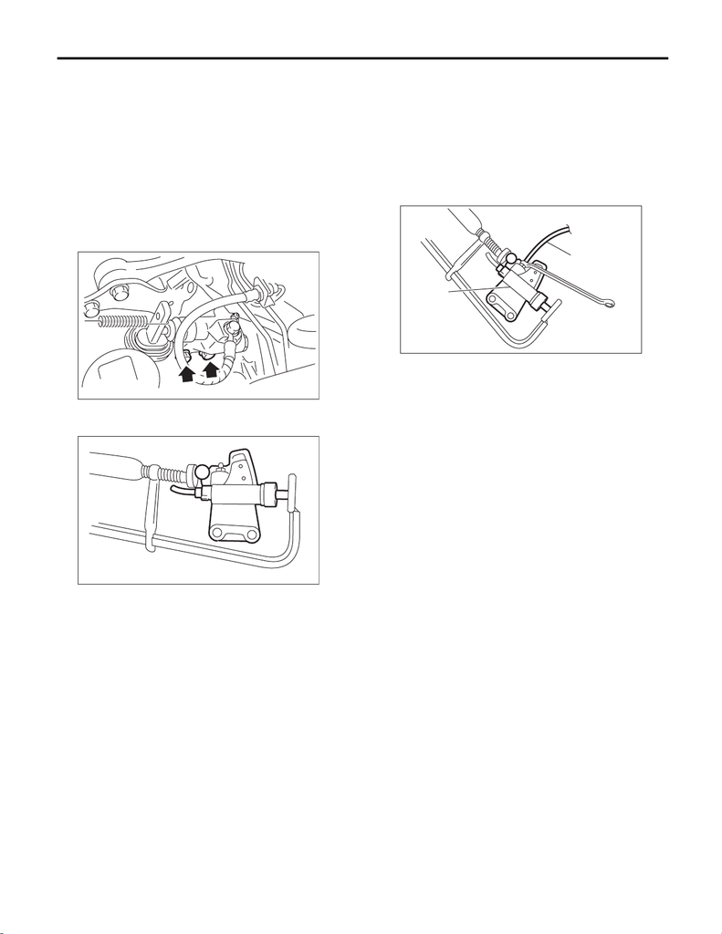

Clutch Fluid Air Bleeding

CLUTCH SYSTEM

9. Clutch Fluid Air Bleeding

A: PROCEDURE

1. STI MODEL

NOTE:

Bleed air from the oil line with help of a co-worker.

1) Remove the intercooler. <Ref. to IN(STI)-13,

REMOVAL, Intercooler.>

2) Remove the operating cylinder.

NOTE:

Do not remove the clutch hose.

3) Hold the piston with a clamp to prevent piston

from popping out.

4) Fit one end of a vinyl tube into the air breather of

the operating cylinder, and put the other end into a

clutch fluid container.

5) Slowly depress the clutch pedal and keep it de-

pressed. Open the air breather to discharge air to-

gether with the clutch fluid. Release the air breather

for 1 or 2 seconds. Next, close the air breather, and

slowly release the clutch pedal.

NOTE:

When performing this procedure, place the screw

portion of the air breather higher than the end of op-

erating cylinder.

6) Repeat procedure 5), until there are no more air

bubbles appearing from the air breather.

CAUTION:

Cover the air breather with cloth to prevent

clutch fluid from being splashed on surround-

ing parts when loosening the breather.

7) Tighten the air breather.

Tightening torque:

7.8 N·m (0.8 kgf-m, 5.8 ft-lb)

8) Install the operating cylinder.

Tightening torque:

41 N·m (4.2 kgf-m, 30.2 ft-lb)

9) After stepping on the clutch pedal, make sure

that there are no leaks evident in the entire clutch

system.

10) After bleeding the air from clutch system, en-

sure that the clutch operates properly.

11) Install the intercooler. <Ref. to IN(STI)-14, IN-

STALLATION, Intercooler.>

CL-00422

CL-00247

(A) Operating cylinder

(B) Vinyl tube

(A)

CL-00248

(B)

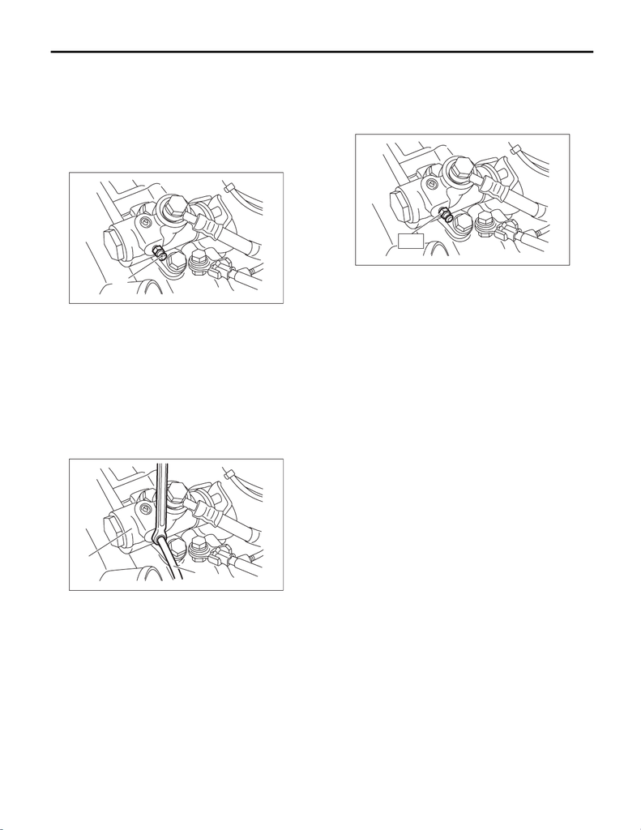

Clutch Fluid Air Bleeding

CLUTCH SYSTEM

2. EXCEPT FOR STI MODEL

NOTE:

Bleed air from the oil line with help of a co-worker.

1) Remove the intercooler. <Ref. to IN(w/o STI)-38,

REMOVAL, Intercooler.>

2) Fit one end of a vinyl tube into the air breather of

the operating cylinder, and put the other end into a

clutch fluid container.

3) Slowly depress the clutch pedal several times

and keep it depressed. Open the air breather to dis-

charge air together with the clutch fluid. Release

the air breather for 1 or 2 seconds. Next, close the

air breather, and slowly release the clutch pedal.

CAUTION:

Cover the air breather with cloth to prevent

clutch fluid from being splashed on surround-

ing parts when loosening the breather.

4) Repeat procedure 3), until there are no more air

bubbles appearing from the air breather.

5) Tighten the air breather.

Tightening torque:

T: 7.8 N·m (0.8 kgf-m, 5.8 ft-lb)

6) After stepping on the clutch pedal, make sure

that there are no leaks evident in the entire clutch

system.

7) After bleeding the air from clutch system, ensure

that the clutch operates properly.

8) Install the intercooler. <Ref. to IN(w/o STI)-41,

INSTALLATION, Intercooler.>

(A) Air breather

(A) Operating cylinder

(B) Vinyl tube

CL-00777

(A)

CL-00711

(B)

(A)

CL-00712

T